# Quiz 01

Week 02

Please place your name in the upper-right corner.

1. Last week in lab you learned about some R basics. Please:  
   1.1. Name three data types in R.  
   1.2. Name the two types of data structures that are 2-dimensional and note which has homogeneous data types and which heterogeneous.
2. We represent population change as $\Delta N = N_{t} - N_{t-1}$. The units for $N$ are $[\text{individuals}]/[\text{area}]$ or, alternatively written, $[\text{individuals}][\text{area}]^{-1}$. Remember when you add or subtract units, they remain unchanged; i.e., the right-hand side equation in the first sentence has units of $[\text{individuals}][\text{area}]^{-1} - [\text{individuals}][\text{area}]^{-1} = [\text{individuals}][\text{area}]^{-1}$. When you multiply units they square; e.g., the area of a rectangle has units of length squared because it is a side (units in length) times another side (units in length). With division, like speed (i.e., velocity), it’s distance units of distance divided by time. Notice, too, that the units balance between the left- and right-hand sides balance.  
   With all of that, the book reads that populations change $\Delta N = bN_{t-1} - dN_{t-1}$. $b$ is the per-capita birth rate and $d$ is the per-capita death rate. Please justify why $b$ and $d$ are called “per-capita” by finding the units of $b$ and $d$ while remembering that the left- and right-hand sides of the equation must balance.
3. If in year 2022, female white-footed mouse (*Peromyscus leucopus*) density is 0.1 / ha here in Maine forests. Lifespans are around 1 year for this species. If females produce 2 female pups per year, how many female mice would we expect after 7 years? (No need to recall an equation, just arithmetically trudge through.)

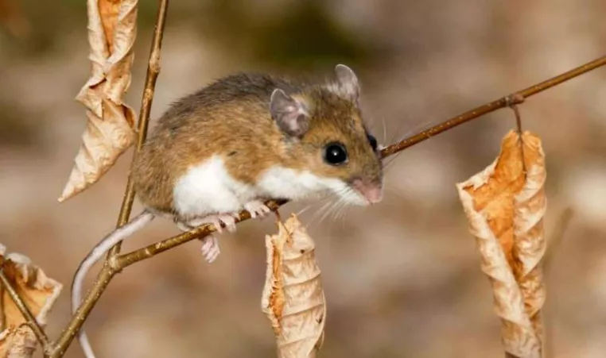

   (So cute)
4. If in year 2022, female white-footed mouse (*Peromyscus leucopus*) density is $N_{2022}$ / ha here in Maine forests. Lifespans are around 1 year for this species. If females produce $\lambda$ female pups per year, how many female mice would we expect after $t$ years? (This is the same question as above, but with parameter names instead of numbers.)
5. Please make 3 graphs below, based on the data your generated in question 3. Please make the first as a time series; i.e., a graph with time (years) on the horizontal axis and the variable (density) on the vertical axis. Second, plot change against density; i.e., from question 2, a graph with $N_t$ on the horizontal axis and population change ($\Delta N$) on the vertical axis. Last, please plot the per-capita change against density; i.e., a graph with $N_t$ on the horizontal axis and per-capita change ($\Delta N/N_t$) on the vertical axis.

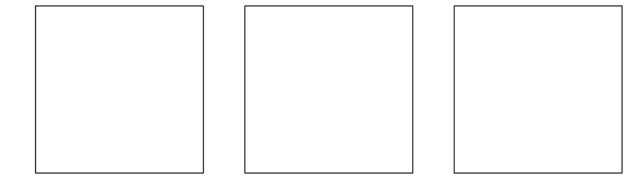